# lab4YG

```r
library(data.table)
```

```r
library(leaflet)
```

```r
library(tidyverse)
```

#1

```r
if (!file.exists("met_all.gz"))
  download.file(
    url = "https://raw.githubusercontent.com/USCbiostats/data-science-data/master/02_met/met_all.gz",
    destfile = "met_all.gz",
    method   = "libcurl",
    timeout  = 60
    )
met <- data.table::fread("met_all.gz")
```

#2:

```r
met <- met[temp >= -17][elev == 9999.0, elev :=NA]
```

```r
met[, week := week(as.Date(paste(year, month, day, sep = "-")))]
```

```r
met <- met[week == min(week, na.rm = TRUE)]
```

```r
met_avg <- met[, .(
  temp      = mean(temp, na.rm = TRUE),
  rh        = mean(rh, na.rm = TRUE),
  wind.sp   = mean(wind.sp, na.rm = TRUE),
  vis.dist  = mean(vis.dist, na.rm = TRUE),
  dew.point = mean(dew.point, na.rm = TRUE),
  lat       = mean(lat, na.rm = TRUE),
  lon       = mean(lon, na.rm = TRUE),
  elev      = mean(elev, na.rm = TRUE)
), by = "USAFID"]
```

```r
met_avg$region <- ifelse(met_avg$lon > -98 & met_avg$lat > 39.71, "north east",
                  ifelse(met_avg$lon > -98 & met_avg$lat < 39.71, "south east",
                  ifelse(met_avg$lon <= -98 & met_avg$lat > 39.71, "north west",
                         "south west")))
```

```r
met_avg$elev_cat <- ifelse(met_avg$elev> 252, "high", "low")
```

```r
table(met_avg$region)
```

```
north east north west south east south west
       484        146        649        297
```

#3

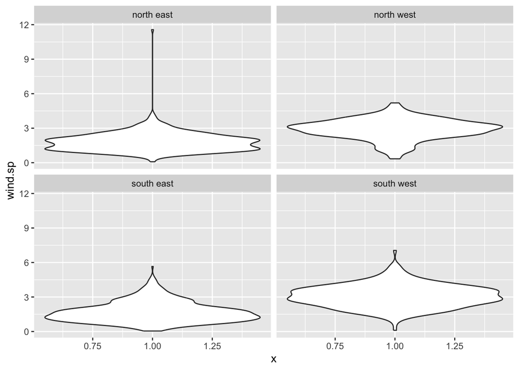

```r
met_avg %>%
  filter(!is.na(region)) %>%
  ggplot() +
    geom_violin(mapping = aes(y = wind.sp, x = 1)) +
    facet_wrap(~ region, nrow = 2)
```

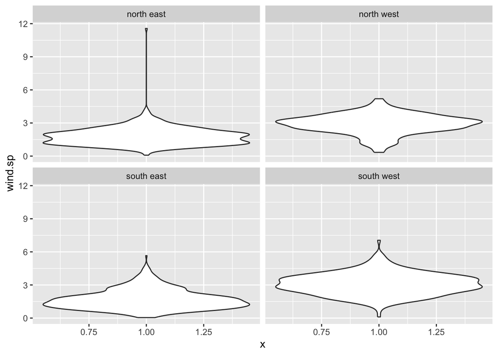

```r
met_avg %>%
  filter(!is.na(wind.sp)) %>%
  ggplot() +
    geom_violin(mapping = aes(y = wind.sp, x = 1)) +
    facet_wrap(~ region, nrow = 2)
```

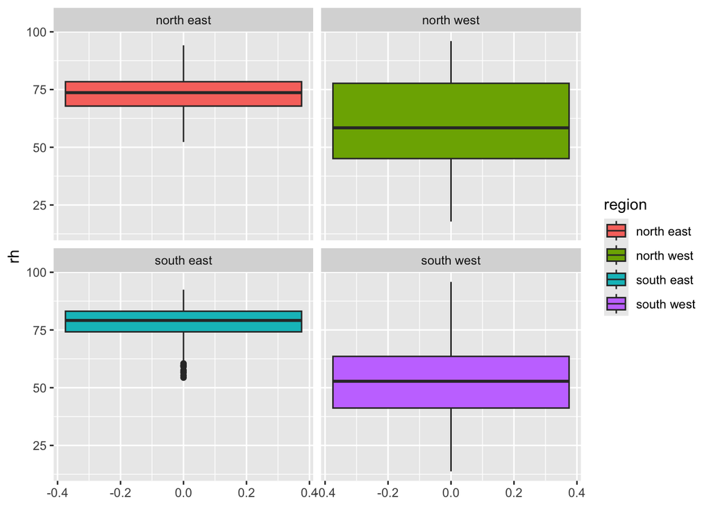

```r
met_avg %>%
  filter(!(region %in% NA)) %>%
  ggplot() +
    geom_boxplot(mapping = aes(y = rh, fill=region)) +
    facet_wrap(~ region, nrow = 2)
```

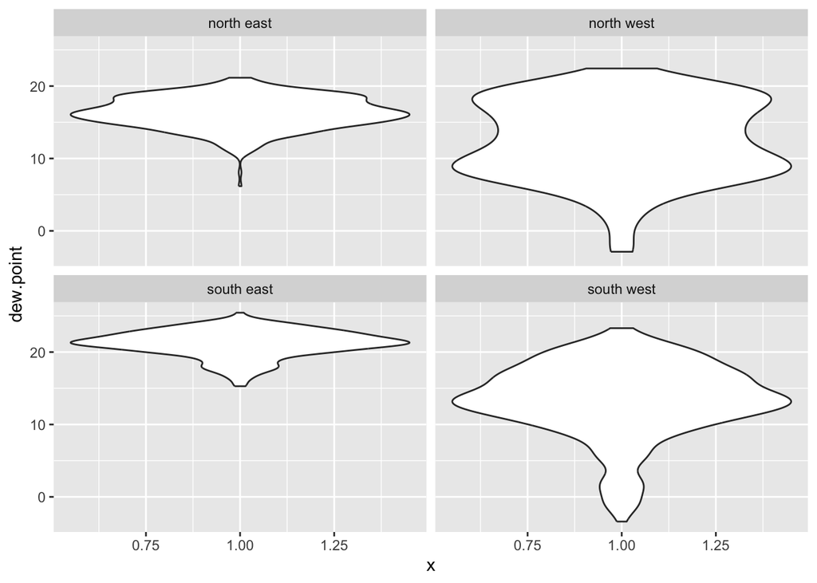

```r
met_avg %>%
  filter(!(dew.point %in% NA)) %>%
  ggplot() +
    geom_violin(aes(y = dew.point, x = 1)) +
    facet_wrap(~ region, nrow = 2)
```

description: The width of each violin shows the density of observations at different dew point values.North east: Concentrated around 15–20, with some values as low as 5. North west: Broader spread, ranging from near 0 to ~22, with many values around 10–20. South east: Clustered high around 18–22, with fewer low values. South west: Widest spread, including very low dew points near 0, but with density concentrated between ~10–20.

#4:

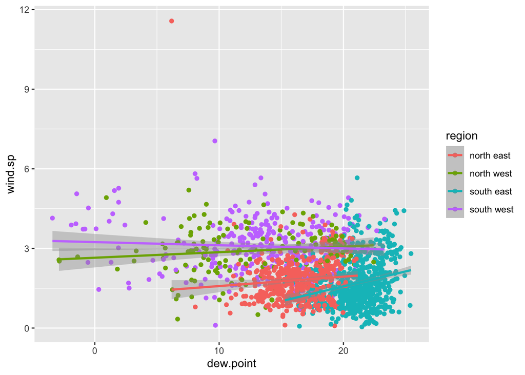

```r
met_avg %>%
  filter(!is.na(dew.point)) %>%
  ggplot(aes(x = dew.point, y = wind.sp, color = region)) +
    geom_jitter() +
    stat_smooth(method = "lm")
```

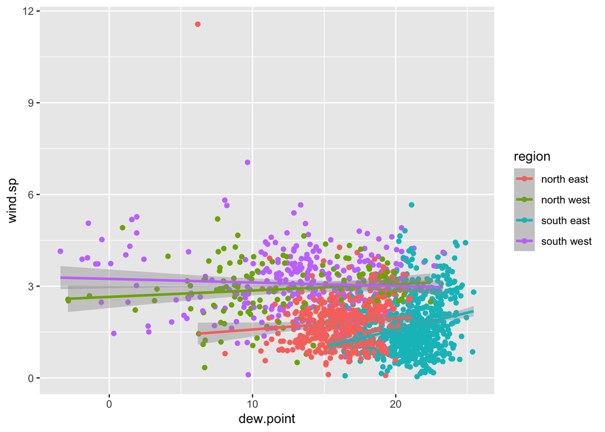

```r
met_avg %>%
  filter(!is.na(dew.point) & !is.na(wind.sp)) %>%
  ggplot(aes(x = dew.point, y = wind.sp, color = region)) +
    geom_jitter() +
    stat_smooth(method = "lm")
```

#5:

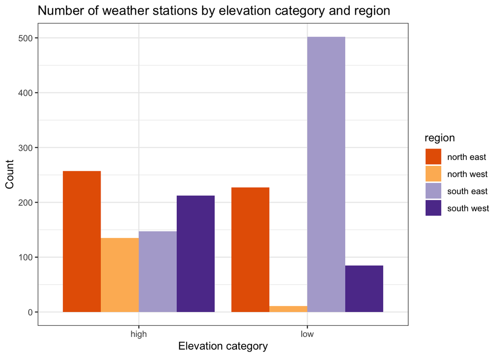

```r
met_avg %>%
  filter(!is.na(elev_cat)) %>%
  ggplot() +
  geom_bar(mapping = aes(x = elev_cat, fill = region), position = "dodge") +
  scale_fill_brewer(palette = "PuOr") +
  labs(
    title = "Number of weather stations by elevation category and region",
    x = "Elevation category",
    y = "Count"
  ) +
  theme_bw()
```

The south east region has by far the most low-elevation stations, while the north east region has a strong presence at both elevation levels. The north west has relatively few stations in total, especially at low elevation.

#6:

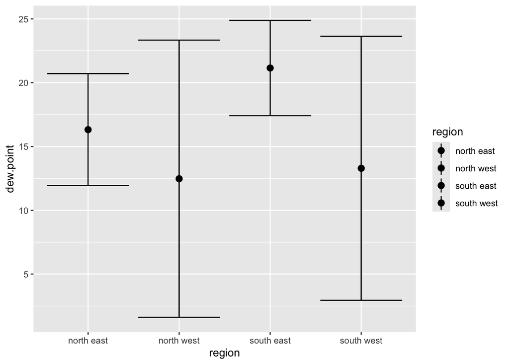

```r
met_avg %>%
  filter(!is.na(dew.point)) %>%
  ggplot(mapping = aes(x = region, y = dew.point, fill = region)) +
  stat_summary(fun.data = "mean_sdl", geom = "errorbar") +
  stat_summary(fun.data = "mean_sdl")
```

South east has the highest average dew point (~21), with relatively small variation compared to others. North east also has a moderately high dew point (~16). South west and especially north west show lower average dew points (~12–13), but also much wider error bars, meaning dew point values there are more variable.Overall, there are regional differences in dew point, with southern and eastern regions tending to have higher averages, while western regions have more variability.

#7

```r
met_avg2<-met_avg[!is.na(rh)]
top10 <- met_avg2[rank(-rh) <= 10]
rh_pal = colorNumeric(c('lightblue','purple','lightyellow'), domain=met_avg2$rh)
leaflet(met_avg2) %>%
  addProviderTiles("OpenStreetMap") %>%
  addCircles(
    lat = ~lat, lng = ~lon,
    color = ~rh_pal(rh),
    label = ~paste0(round(rh, 2), " rh"),
    opacity = 1, fillOpacity = 1, radius = 500
  ) %>%
  addMarkers(
    lat = ~lat, lng = ~lon,
    label = ~paste0(round(rh, 2), " rh"),
    data = top10
  ) %>%
  addLegend(
    position = "bottomleft",
    pal = rh_pal,
    values = met_avg2$rh,
    title = "Relative Humidity",
    opacity = 1
  )
```

[interactive chart not shown]

The map gives a geographic view of relative humidity across the U.S., showing regional contrasts between dry western areas and more humid eastern/southern areas, with the most humid stations marked by blue pins.

#8

```r
temp_region <- met_avg %>%
  group_by(region) %>%
  summarise(avg_temp = mean(temp, na.rm = TRUE), .groups = "drop")

print(temp_region)
```

```
# A tibble: 4 × 2
  region     avg_temp
  <chr>         <dbl>
1 north east     22.0
2 north west     22.5
3 south east     25.7
4 south west     25.8
```

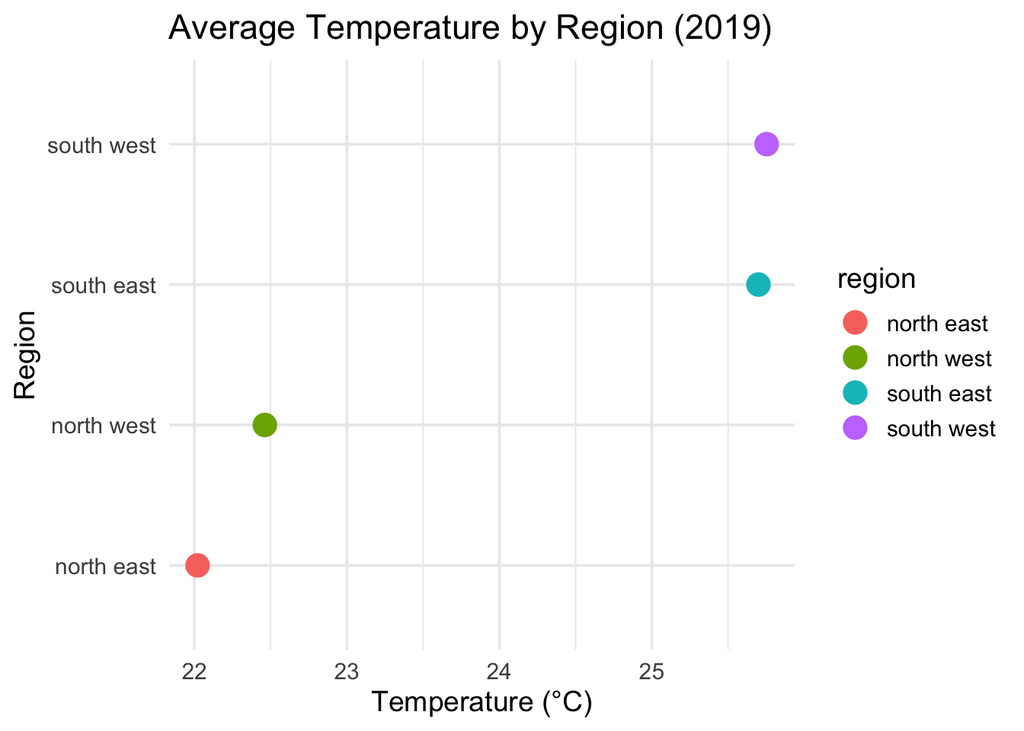

```r
ggplot(temp_region, aes(x = avg_temp, y = region, color = region)) +
  geom_point(size = 5) +
  labs(title = "Average Temperature by Region (2019)",
       x = "Temperature (°C)", y = "Region") +
  theme_minimal(base_size = 14)
```

In 2019, the average temperature varied across regions. Each region is plotted once, making it easy to compare which region was warmer or cooler on average